# NBS optimization- Yucatan Peninsula

Jeronimo Rodriguez Escobar

# 1. Introduction

This report presents a preliminary approach to estimate potential ecosystem service provision gains derived from restoration across five study areas prioritized in WWF’s Nature-Based Solutions Originating Platform (NbS-OP)and optimize restoration interventions.

We evaluated following ecosystem services:

- Nitrogen Export
- Sediment Retention
- Pollination
- Coastal Protection
- Nature Access.

## 1.2 Objectives

- Identify high-value pixels for restoration purposes.
- Estimate potential gains in ecosystem service (ES) provision if a target surface (15.000ha) is restored to a natural vegetation state within the intervention area.

## 1.3 Theoretical Assumptions

- All ecosystem services are equally valuable.
- Restoration likelihood is distributed uniformly across the pixels prioritized for restoration.
- The total area to restore is known in advance, the exact location of the restoration action within the potential restoration area is not determined yet, as it is contingent on variables such as: The willingness of landowners and managers to participate in the project and the ability to secure control over land during the intended intervention duration.

The use of stratified random sampling ensures that representative of the entire population (i.e., all pixels with restoration potential within the AOI). By assessing the results from multiple repetitions, the overall estimates are less susceptible to the influence of individual sample variations and provide a more accurate representation of the true population values.

## Intervention Area

The intervention area is located in the Yucatan Peninsula, and encompasses biodiversity corridors and existing protected areas across key ecosystems including the northern shoreline.

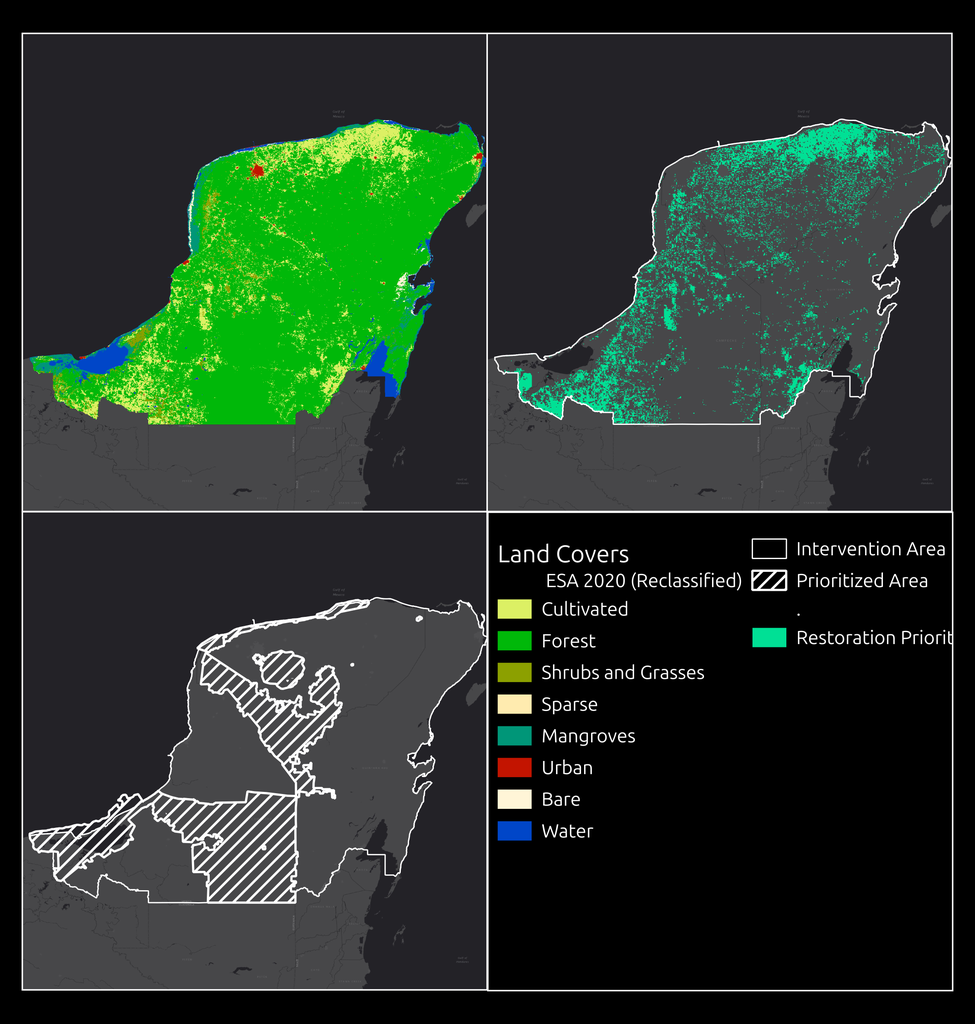

Yucatan 2020 ESa Land Cover map (reclassified) and Restoration Priority Areas

# 2. Methods

## 2.1 Input Data

- **Ecosystem Service Data:** Chaplin-Kramer et al. (2022) [Mapping the planet’s critical natural assets](https://www.nature.com/articles/s41559-022-01934-5). Data derived using InVEST, a suite of spatially explicit models that map and quantify nature’s contributions to people. InVEST was developed by the Natural Capital Project, a partnership among Stanford University, the University of Minnesota, The Nature Conservancy, and the World Wildlife Fund.
- **Restoration Potential:** [Adjusted Griscom restoration grided data](https://zenodo.org/records/883444)

Two sets of data were used, the first one representing the baseline for the ecosystem service provision estimated for 2020, and a second one representing potential increase in ecosystem service provision if an area is restored to its potential natural vegetation, except for urban/built-up areas. The following ecosystem services were considered:

1. Nitrogen Export. Derived from the Nitrogen retention modeled using the [**InVEST Nutrient Delivery Ratio**](http://data.naturalcapitalproject.org/invest-releases/3.5.0/userguide/ndr.html). Expressed in kg/pixel/year
2. Sediment Retention. Derived using [**InVEST SDR: Sediment Delivery Ration**](https://storage.googleapis.com/releases.naturalcapitalproject.org/invest-userguide/latest/en/sdr.html). Values in ton/pixel/year
3. Pollination. Derived from [**InVEST SDR: Pollinator Abundance Model**](https://storage.googleapis.com/releases.naturalcapitalproject.org/invest-userguide/latest/en/croppollination.html). Units represent Polllination Change in people fed on HABitat. More information in [**Chaplin-Kramer, et al. 2022**](https://static-content.springer.com/esm/art%3A10.1038%2Fs41559-022-01934-5/MediaObjects/41559_2022_1934_MOESM1_ESM.pdf)
4. Coastal Protection. Unitless measure, refers to a derived vulnerability index. [**InVEST Coastal Vulnerability Model**](https://storage.googleapis.com/releases.naturalcapitalproject.org/invest-userguide/latest/en/coastal_vulnerability.html)
5. Nature Access represented as [**the number of people within 1 hour travel of natural and semi-natural lands**](https://github.com/springinnovate/distance-to-hab-with-friction) (Chaplin-Kramer et al, 2022).

## 2.2 Area of Interest Definition and Sampling

- Define the area of interest (AOI) within the intervention area extent. This AOI represents the spatial extent from which the samples will be drawn. In this specific case, the AOI is set to 15.000 ha.
- Calculate the Sample Size: Based on the resolution of the raster and the desired AOI, the required number of pixels to be sampled is calculated. This ensures that the total area covered by the sampled pixels corresponds to the defined AOI.
- Perform repeated stratified random sampling: Random sampling of pixels within the defined AOI. The sampling process is repeated 30 times (Bootstrapping) to estimate the sampling distribution of a statistic.

Calculate Summary Statistics: For each repetition, the mean, standard deviation, and 95% confidence intervals are calculated for each band in the raster dataset. This provides a measure of the central tendency and variability of the sampled data.

Synthesize Results: The results from all repetitions are combined to calculate an overall mean and confidence interval for each band. This provides a more robust estimate of the expected values, effectively correcting for potential outliers and reducing the influence of individual sample variations.

The model can be refined by incorporating additional parameters, such as minimum distance to boundaries, distance between points, topography, or inhabited areas. By definition, coastal risk protection only occurs at the coast; and this has to be kept in mind for example by setting sampling weights for the different services or derived from population density data. This approach provides a distribution of possible values and allows for the calculation of confidence intervals. By synthesizing the results from multiple repetitions, the estimates are less susceptible to individual sample variations.

## 2.3 Processing Environment

Spatial Raster Processing Tools: The `terra`, `dplyr`, and `sf` packages in **R** were used for analysis. Data visualization was performed using `ggplot2`.

## 3. Results

# Summarize (get baseline )

## Load Restoration layers, align and prepare

## 3.1 EStimated ES Gain through Restoration

The estimated gains in ecosystem service provision, (%) are synthetized in following table

Estimated ES Provision Gain in % with Confidence Intervals

[output not shown]

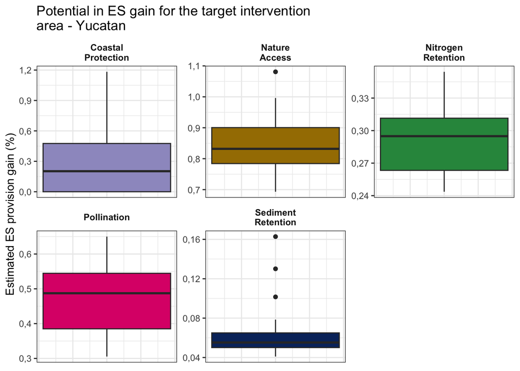

# 3.3 Maximum Return Potential

This maps shows, for each class, the pixles wit hthe highest 10% of the gain values

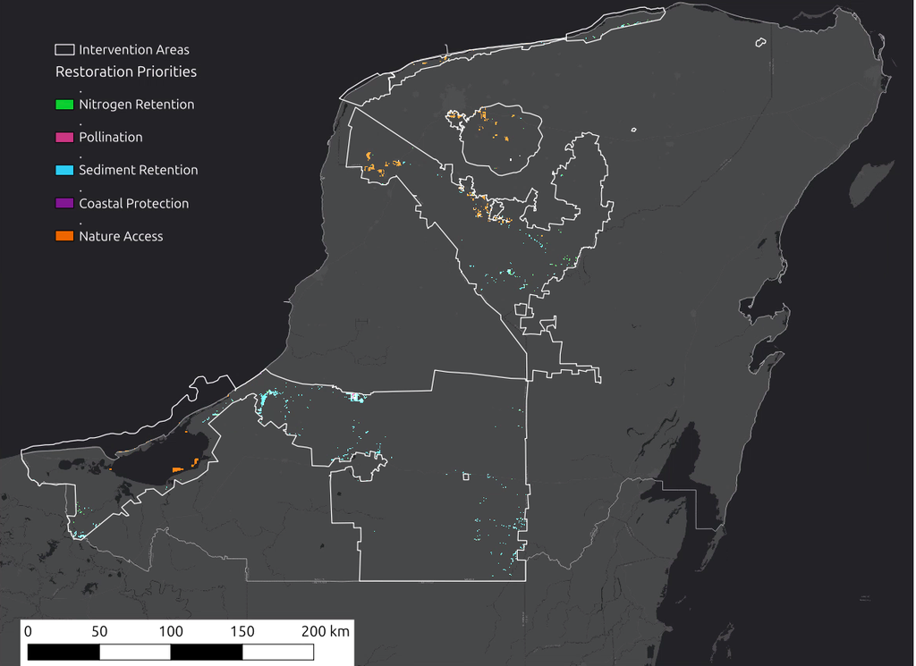

Restoration Priority area per Service (top 10%)